# jl013

Jenna Loesberg

10/15/2019

# Effective Visualizations

Now that you know how to create graphics and visualizations in R, you are armed with powerful tools for scientific computing and analysis. With this power also comes great responsibility. Effective visualizations is an incredibly important aspect of scientific research and communication. There have been several books (see references) written about these principles. In class today we will be going through several case-studies trying to develop some expertise into making effective visualizations.

## Worksheet

**The worksheet questions for today are embedded into the class notes.**

You can download this Rmd file [here](https://github.com/STAT545-UBC/Classroom/blob/master/cm013.Rmd)

Note, there will be very little coding in-class today, but I’ve given you plenty of exercises in the form of a supplemental worksheet (linked at the bottom of this page) to practice with after class is over.

## Resources

1. [Fundamentals of Data Visualization](https://serialmentor.com/dataviz/introduction.html) by Claus Wilke.
2. [Visualization Analysis and Design](https://www-taylorfrancis-com.ezproxy.library.ubc.ca/books/9780429088902) by Tamara Munzner.
3. [STAT545.com - Effective Graphics](https://stat545.com/effective-graphs.html) by Jenny Bryan.
4. [ggplot2 book](https://ggplot2-book.org) by Hadley Wickam.
5. [Callingbull.org](https://callingbull.org/tools.html) by Carl T. Bergstrom and Jevin West.

## Part 1: Warm-up and pre-test [20 mins]

### Warmup:

Write some notes here about what “effective visualizations” means to you. Think of elements of good graphics and plots that you have seen - what makes them good or bad? Write 3-5 points.

1. uncrowded, easy to follow
2. eye catching, not a lot of white space, but no offensive/garish colors
3. axes make sense
4. you’re able to draw your own conlusions from the data

### CQ01: Weekly hours for full-time employees

> Very strong, strong, weak, very week, do not know - Weak, its just showing how many hours they work, not the drivers behind it…just because they work more doesnt mean they’re more motivated…also no measure of uncertainty, errors, sample size. Axes scales are too narrow (if they started it at zero, differences would be less obvious), gridlines and numbers together are too much
- Main takeaway: Summarize the main takeaway from this question/discussion here slightly biased to fit paper’s argument

### CQ02: Average Global Temperature by year

> Yes, No, Do not know - X axis title??? y axis should not start at 0 (cant see any variation and obscures the increase - theres actually a 2 degree increase)
- Main takeaway: Summarize the main takeaway from this question/discussion here
- how you frame data has important implications for takeaways

### CQ03: Gun deaths in Florida

> Very strong, strong, weak, very week, do not know - ery week, they flipped the axis!!!
- Main takeaway: Summarize the main takeaway from this question/discussion here Dont be creative with axis/colors!

## Part 2: Extracting insight from visualizations [20 mins]

Great resource for selecting the right plot: https://www.data-to-viz.com/ ; encourage you all to consult it when choosing to visualize data.

### Case Study 1: Context matters

```r
library(plotly)
library(tidyverse)
library(gapminder)
```

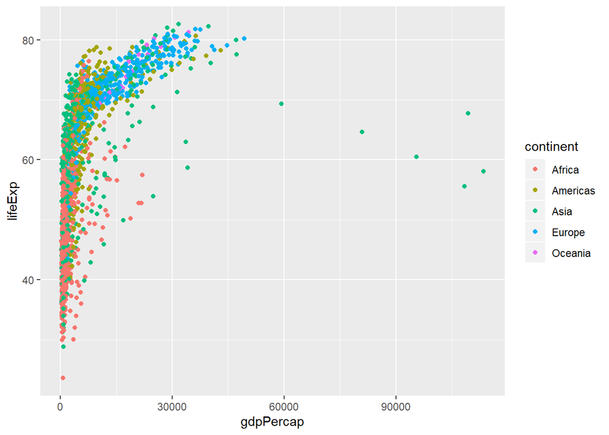

```r
p <-
  ggplot(gapminder, aes(x = gdpPercap, y = lifeExp,
         color = continent)) +
  geom_point()
p
```

```r
#make interacitve
p %>%
  ggplotly()
```

[interactive chart not shown]

```r
#plotly syntax
gapminder %>%
  plot_ly(x = ~gdpPercap,
          y = ~lifeExp,
          color = ~continent,
          type = 'scatter',
          mode = 'markers')
```

[interactive chart not shown]

## Part 3: Principles of effective visualizations [20 mins]

### Make a great plot worse

How many of the principles did you manage to break?

## Plotly demo [10 mins]

Did you know that you can make interactive graphs and plots in R using the plotly library? We will show you a demo of what plotly is and why it’s useful, and then you can try converting a static ggplot graph into an interactive plotly graph.

This is a preview of what we’ll be doing in STAT 547 - making dynamic and interactive dashboards using R!

## Supplemental worksheet (Optional)

You are highly encouraged to the cm013 supplemental exercises worksheet. It is a great guide that will take you through Scales, Colours, and Themes in ggplot. There is also a short guided activity showing you how to make a ggplot interactive using plotly.

- [Supplemental Rmd file here](https://github.com/STAT545-UBC/Classroom/blob/master/tutorials/cm013-supplemental.Rmd)